# Crecimiento del consumo de energia electrica por el uso de criptomonedas

Moises Berrios, Diego De Sousa, Gabriela Machado, Aitor Parrilla

2023-07-20

# Introducción

## Justificación del proyecto

El presente trabajo, tuvo como objetivo, identificar si la minería, las transacciones de las criptomonedas y el valor de las mismas, con sus respectivos consumos de energía, están ejerciendo un aporte significativo en los graves problemas ecológicos que están sucediendo a nivel mundial, como el incremento de la huella de carbono, dado que, es imposible detener el uso creciente de las criptomonedas, por su facilidad de uso inmediato, rapidez, eficiencia, y descentralización automatizada del uso del mismo.

## Planteamiento del problema

> El progresivo desarrollo tecnológico, particularmente en los últimos veinte años, ha tenido un gran impacto sobre la biósfera y la sociedad en general. Ahora que nos encontramos ante la transición del dinero físico al dinero digital, es preciso evaluar las consecuencias de un cambio tan significativo. Lo cierto es que, si bien las criptomonedas brindan la oportunidad de acceder a un sistema transparente, descentralizado y seguro para efectuar transacciones, también representan un importante elemento a considerar cuando nos referimos al aumento del consumo eléctrico mundial. De acuerdo a la Oficina de Política, Ciencia y Tecnología (2022), perteneciente al departamento del gobierno de los Estados Unidos:

> > *Casi todo el consumo de electricidad de los cripto activos es impulsado por los mecanismos de consenso: la tecnología de contabilidad distribuida (DLT) utilizada para minar y verificar los cripto activos. El mecanismo de consenso dominante se llama Prueba de Trabajo (PoW), que es utilizado por las cadenas de bloques Bitcoin y Ethereum. Bitcoin y Ether combinados representan más del 60% de la capitalización total del mercado de los cripto activos. El mecanismo PoW está diseñado para requerir más poder de cómputo a medida que más entidades intentan validar transacciones para obtener una pequeña comisión en monedas, y esta característica ayuda a desincentivar a los actores malintencionados de atacar la red. A partir de agosto de 2022, se estima que Bitcoin representa del 60% al 77% del consumo total de electricidad de los cripto activos a nivel mundial, y Ethereum representa del 20% al 39%.*

> El impacto ambiental de estos cripto activos no es un factor que la mayoría de las personas consideran al momento de invertir, sin embargo, esto se debe en gran medida al desconocimiento y lo poco tangible que resulta dicho fenómeno. Asimismo, existen pocas fuentes que permitan establecer una relación entre el consumo eléctrico y las muchas criptomonedas en existencia; afectando la percepción real de las dimensiones del problema.

## Relevancia del proyecto

La orientación al progreso y al desarrollo tecnológico son dos aspectos que caracterizan a la sociedad contemporánea, no obstante, esto constituye un problema cuando se desestima el impacto ambiental de sus hazañas. A pesar de que las ventajas de las transacciones con criptomonedas son muchas y representan el futuro de la economía mundial, el alto costo energético y las crecientes emisiones de carbono son imposibles de ignorar. En tal sentido, es preciso tomar conciencia, adoptar alternativas y realizar mejoras. El presente proyecto pretende dar un primer paso, aportando una visualización clave del problema que motive al usuario a seguir investigando y a tomar decisiones más conscientes al momento de invertir en activos digitales.

## Interrogantes a evaluar

- ¿Cómo han aumentado las transacciones?

# Metodología

Se definen en este apartado, las metricas a usar, la recopilacion, carga, procesamiento, almacenamiento, limpieza y visualizacion de los datos a usar en este trabajo.

## Justificación de la metodología

La elaboración de un proyecto de informática requiere de una metodología adecuada que permita una planificación rigurosa y una fácil corrección y mantenimiento del proyecto, a lo largo de su ciclo de vida. Una metodología en etapas, es esencial para lograr estos objetivos. Incluyendo la recopilación y limpieza de datos, el procesamiento y almacenamiento de datos, el análisis de datos, la definición y uso de métricas, y la presentación de resultados. Cada una de estas etapas es esencial para el éxito del proyecto. El uso de métricas es importante, porque permite evaluar el desempeño del proyecto en términos cuantitativos y realizar mejoras continuas a lo largo del tiempo. Además, el uso de librerías de R como ggplot2, tidyverse, scales, readxl, openxlsx y zoo permite realizar análisis estadísticos y gráficos precisos y personalizados, que facilitan, el análisis, la interpretación los resultados, para identificar las respectivas relaciones entre datos trabajados y su posible solución.

## Métricas

Se utilizaron las siguientes librerías de R:

- gridExtra: permite combinar y organizar gráficos realizados con el paquete ggplot2, capaz de organizar y combinar múltiples gráficos para crear diseños personalizados en RMarkdown
- tidiverse: Es una colección de paquetes de R diseñados para trabajar de manera conjunta y proporcionar una interfaz coherente y eficiente para el análisis de datos. Incluye paquetes como dplyr, que proporciona funciones para la manipulación de datos de forma rápida y sencilla. con verbos como filter, select, mutate, arrange y group_by para realizar operaciones comunes en tablas de datos.
- ggplot2: Incluido en tidyverse, es una poderosa librería para crear gráficos elegantes y versátiles basados en la gramática de gráficos. Permite construir visualizaciones con facilidad y ofrece un alto nivel de personalización.
- scales: parte del ecosistema ggplot2 y proporciona funciones para formatear y ajustar escalas de ejes y leyendas en gráficos creados con ggplot2
- readxl: Permite la carga y lectura de archivos Excel
- openxlsx: Permite modificacion y creacion de archivos Excel
- zoo: “Z’s Ordered Observations”, herramienta que destaca su enfoque en el ordenamiento de observaciones y la manipulación de datos de series de tiempo.

```r
library(gridExtra)
library(tidyverse)
library(ggplot2)
library(scales)
library(readxl)
library(openxlsx)
library(zoo)
```

## Recopilación de archivos

De la recolección obtenida, se tuvo las siguientes descripciones para la data:

```r
coin_Aave <- read_csv("Dataframes/coin_Aave.csv")
coin_BinanceCoin <- read_csv("Dataframes/coin_BinanceCoin.csv")
coin_Bitcoin <- read_csv("Dataframes/coin_Bitcoin.csv")
coin_Cardano <- read_csv("Dataframes/coin_Cardano.csv")
coin_ChainLink <- read_csv("Dataframes/coin_ChainLink.csv")
coin_Cosmos <- read_csv("Dataframes/coin_Cosmos.csv")
coin_CryptocomCoin <- read_csv("Dataframes/coin_CryptocomCoin.csv")
coin_Dogecoin <- read_csv("Dataframes/coin_Dogecoin.csv")
coin_EOS <- read_csv("Dataframes/coin_EOS.csv")
coin_Ethereum <- read_csv("Dataframes/coin_Ethereum.csv")
coin_Iota <- read_csv("Dataframes/coin_Iota.csv")
coin_Litecoin <- read_csv("Dataframes/coin_Litecoin.csv")
coin_Monero <- read_csv("Dataframes/coin_Monero.csv")
coin_NEM <- read_csv("Dataframes/coin_NEM.csv")
coin_Polkadot <- read_csv("Dataframes/coin_Polkadot.csv")
coin_Solana <- read_csv("Dataframes/coin_Solana.csv")
coin_Stellar <- read_csv("Dataframes/coin_Stellar.csv")
coin_Tether <- read_csv("Dataframes/coin_Tether.csv")
coin_Tron <- read_csv("Dataframes/coin_Tron.csv")
coin_USDCoin <- read_csv("Dataframes/coin_USDCoin.csv")
coin_Uniswap <- read_csv("Dataframes/coin_Uniswap.csv")
coin_WrappedBitcoin <- read_csv("Dataframes/coin_WrappedBitcoin.csv")
coin_XRP <- read_csv("Dataframes/coin_XRP.csv")
MES_0423 <- read_csv("Dataframes/MES_0423.csv")
BTC_Footprints_v1 <- read_excel("Dataframes/BTC_Footprints_v1.xlsx")
owid_co2_data <- read_excel("Dataframes/owid-co2-data.xlsx")
```

## Carga de archivos

Se subió al vector, todos los nombres de archivos a utilizar en el proyecto

```r
coins_ALL_Vector <- c(list(coin_Aave),
                      list(coin_BinanceCoin),
                      list(coin_Bitcoin),
                      list(coin_Cardano),
                      list(coin_ChainLink),
                      list(coin_ChainLink),
                      list(coin_Cosmos),
                      list(coin_CryptocomCoin),
                      list(coin_Dogecoin),
                      list(coin_EOS),
                      list(coin_Ethereum),
                      list(coin_Iota),
                      list(coin_Litecoin),
                      list(coin_Monero),
                      list(coin_NEM),
                      list(coin_Polkadot),
                      list(coin_Solana),
                      list(coin_Stellar),
                      list(coin_Tether),
                      list(coin_Tron),
                      list(coin_Uniswap),
                      list(coin_USDCoin),
                      list(coin_WrappedBitcoin),
                      list(coin_XRP))
```

## Procesamiento y almacenamiento de archivos

Procesamiento de los archivos, transformados a dataframes, con el conjunto de paquetes de tidyverse.

```r
COINS_ALL_DF <- data.frame()
for (DF in coins_ALL_Vector) {
  COINS_ALL_DF <- rbind(COINS_ALL_DF,DF)}
COINS_ALL_DF <- COINS_ALL_DF %>% mutate(Date=as.yearmon(Date, format = "%y-%m-%d"))

COINS_ALL_DF_VOL <- COINS_ALL_DF %>%
  group_by(Name) %>%
  summarise(Volume=sum(Volume))

COINS_ALL_DF_VOL <- COINS_ALL_DF_VOL %>% mutate(Percentage = 100*Volume/sum(Volume))

coins <- COINS_ALL_DF[COINS_ALL_DF$Name %in% c('Ethereum','Bitcoin','Tether'),]

power_df <- MES_0423
names(power_df) <- power_df[8,]
colnames(power_df)[5] <- "Amount"
power_df <- power_df[-c(1:8),]
power_df <- power_df %>%
  mutate(Time = Time %>%
           str_replace_all(" ", "-"))
power_df <- power_df %>% mutate(Time=as.yearmon(Time,"%b-%Y"))
power_df <- power_df %>%
            filter(!(Country %in% c("IEA Total","OECD Americas","OECD Asia Oceania","OECD Europe","OECD Total"))) %>%
            filter(Product == "Total Combustible Fuels")
```

## Limpieza de los datos

Utilizando la libreria de tidyverse, con el componente de dplyr y sus verbos, para la manipulacion de los datos, se realiza de la siguiente manera:

```r
power_bt_df <- BTC_Footprints_v1

## resolucion de fechas en distintos formatos
power_bt_df_g <- dplyr::filter(power_bt_df, grepl('/', Date))
power_bt_df_w <- dplyr::filter(power_bt_df, !grepl('/', Date))

##tratado de fechas a numero
power_bt_df_w$Date <- as.numeric(power_bt_df_w$Date)
##vuelta de fecha a formato aceptado en Excel
power_bt_df_w$Date <- as.Date(power_bt_df_w$Date,origin = "1899-12-30")

##pase de formato year a month
power_bt_df_g <- power_bt_df_g %>% mutate(Date=as.yearmon(Date,"%m/%d/%Y"))

##arreglado char para que R se olvide del formato original en la que las tenia
##arreglado fecha otra vez pero con distinto formato
##arreglado yearmon (ambiguo)
power_bt_df_w <- power_bt_df_w %>%
  mutate(Date = Date %>%
           str_replace_all("-", "/"))
power_bt_df_w <- power_bt_df_w %>% mutate(Date=as.character(Date))
power_bt_df_w <- power_bt_df_w %>% mutate(Date=as.Date(Date,"%Y/%d/%m"))
power_bt_df_w <- power_bt_df_w %>% mutate(Date=as.yearmon(Date))

##Las fechas raras (Weird) + las fechas buenas (Good) = dataframe original
power_bt_df <- rbind(power_bt_df_g,power_bt_df_w)


##quitado lineas en blanco, nombrado a las columnas, quito aquellas cosas que no sean paises
##formateado la fecha para que sea "yearmon"
power_df_total <- MES_0423
names(power_df_total) <- power_df_total[8,]
colnames(power_df_total)[5] <- "Amount"
power_df_total <- power_df_total[-c(1:8),]
power_df_total <- power_df_total %>%
  mutate(Time = Time %>%
           str_replace_all(" ", "-"))
power_df_total <- power_df_total %>% mutate(Time=as.yearmon(Time,"%b-%Y"))
power_df_total <- power_df_total %>%
  filter(!(Country %in% c("IEA Total","OECD Americas","OECD Asia Oceania","OECD Europe","OECD Total"))) %>%
  filter(Product == "Electricity" & Balance == "Final Consumption (Calculated)")


power_df <- power_df %>%
  group_by(Time,Product,Unit) %>%
  summarize(Avg_amount = sum(Amount))

power_df_total <- power_df_total %>%
  group_by(Time,Product,Unit) %>%
  summarize(Avg_amount = sum(Amount))

power_bt_df_summary <- power_bt_df %>%
  group_by(Date) %>%
  summarize(Avg_Energy = (mean(BTCENEGUE)))

value_df_summary <- coins %>%
  group_by(Date) %>%
  summarize(Avg_Value = (mean(High)+mean(Low))/2)

volumen_df_summary <- coins %>%
  group_by(Date)  %>%
  summarize(Volume = mean(Volume))

power_bt_power_total_df <- left_join(power_df_total,power_bt_df_summary,by=c("Time"="Date"))

power_value_df <- left_join(value_df_summary,power_df,by=c("Date"="Time"))

power_volume_df <- left_join(volumen_df_summary,power_df,by=c("Date"="Time"))

power_total_value_df <- left_join(value_df_summary,power_df_total,by=c("Date"="Time"))

power_total_volume_df <- left_join(volumen_df_summary,power_df_total,by=c("Date"="Time"))
```

## Visualización

Se visualiza un resumen de datos que contienen los dataframes

```r
summary(COINS_ALL_DF)
```

```
##       SNo           Name              Symbol               Date
##  Min.   :   1   Length:38467       Length:38467       Min.   :2013
##  1st Qu.: 416   Class :character   Class :character   1st Qu.:2017
##  Median : 898   Mode  :character   Mode  :character   Median :2019
##  Mean   :1044                                         Mean   :2019
##  3rd Qu.:1546                                         3rd Qu.:2020
##  Max.   :2991                                         Max.   :2022
##       High               Low                Open              Close
##  Min.   :    0.00   Min.   :    0.00   Min.   :    0.00   Min.   :    0.00
##  1st Qu.:    0.09   1st Qu.:    0.08   1st Qu.:    0.08   1st Qu.:    0.08
##  Median :    1.01   Median :    1.00   Median :    1.00   Median :    1.00
##  Mean   :  979.71   Mean   :  918.89   Mean   :  950.07   Mean   :  951.81
##  3rd Qu.:   28.31   3rd Qu.:   25.45   3rd Qu.:   27.06   3rd Qu.:   27.13
##  Max.   :64863.10   Max.   :62208.96   Max.   :63523.75   Max.   :63503.46
##      Volume            Marketcap
##  Min.   :0.000e+00   Min.   :0.000e+00
##  1st Qu.:5.013e+06   1st Qu.:2.294e+08
##  Median :8.487e+07   Median :1.349e+09
##  Mean   :2.939e+09   Mean   :1.496e+10
##  3rd Qu.:9.345e+08   3rd Qu.:5.036e+09
##  Max.   :3.510e+11   Max.   :1.186e+12
```

Resumen estadístico arrojado, de la data de las criptomonedas

```r
nrow(COINS_ALL_DF)
```

```
## [1] 38467
```

Numero de filas totales para la data de las criptomonedas

```r
ncol(COINS_ALL_DF)
```

```
## [1] 10
```

Numero de columnas totales utilizadas para la data de las criptomonedas

```r
summary(power_df)
```

```
##       Time        Product              Unit             Avg_amount
##  Min.   :2010   Length:160         Length:160         Min.   : 461798
##  1st Qu.:2013   Class :character   Class :character   1st Qu.: 554857
##  Median :2017   Mode  :character   Mode  :character   Median : 952552
##  Mean   :2017                                         Mean   : 844798
##  3rd Qu.:2020                                         3rd Qu.:1037409
##  Max.   :2023                                         Max.   :1262948
```

Resumen estadístico arrojado, de la data de energia recolectada de los distintos paises

```r
nrow(power_df)
```

```
## [1] 160
```

Numero de filas totales para la data de la energia registrada

```r
ncol(power_df)
```

```
## [1] 4
```

Numero de columnas totales utilizadas para la data de la energia registrada

Con la libreria ggplot2, se realizan visualizaciones de distintos factores para su posterior analisis.

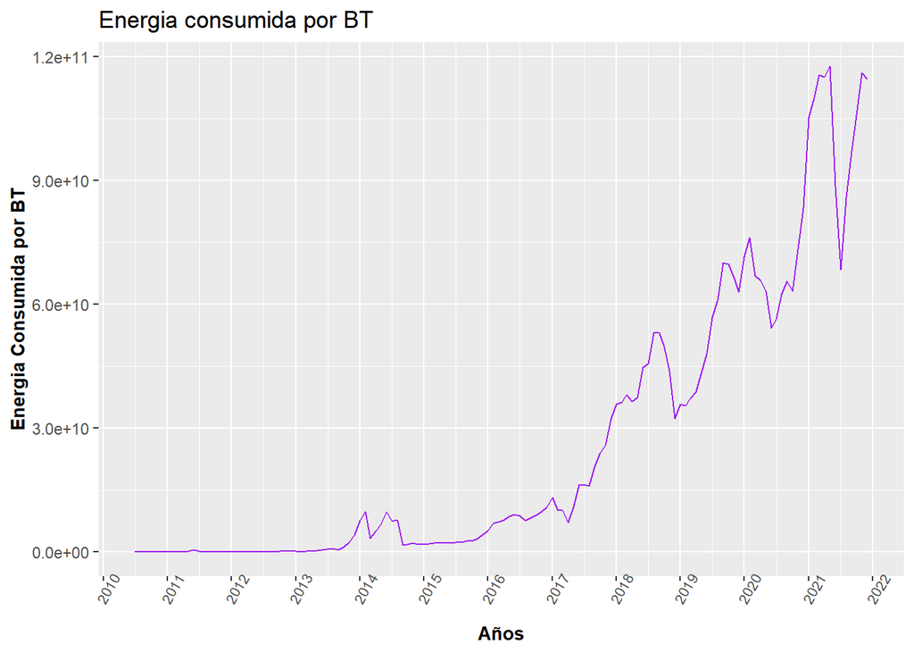

```r
power_bt <- power_bt_df_summary %>%
  ggplot() +
  geom_line(aes(x = as.Date(Date,format = "%y-%m-%d"), y = Avg_Energy),color="purple",fill="purple") +
  labs(y="Energia Consumida por BT", x="Años")+
  scale_x_date(date_breaks = "1 year",date_labels = "%Y")+
  ggtitle("Energia consumida por BT")+
  theme(axis.title=element_text(size=10,face="bold"),axis.text.x = element_text(size = 8,angle = 60))
power_bt
```

**Figura 1: Energia consumida por BT**

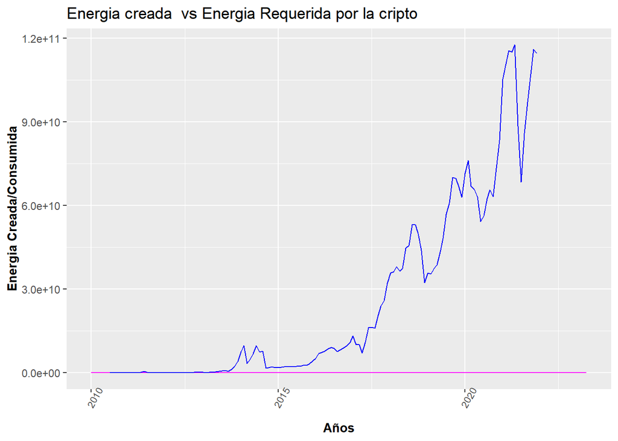

```r
power_bt_power <- power_bt_power_total_df  %>%
  ggplot() +
  labs(y="Energia Creada/Consumida", x="Años")+
  ggtitle("Energia creada  vs Energia Requerida por la cripto")+
  geom_line(aes(x = as.Date(Time,format = "%y-%m-%d"), y = Avg_amount,color="power")) +
  geom_line(aes(x = as.Date(Time,format = "%y-%m-%d"), y = Avg_Energy,color="power cripto")) +
  scale_color_manual(name="Fuente de poder",breaks=c('energia creada total','energia requerida cripto'),values = c('power'='magenta','power cripto'='blue'))+
  theme(axis.title=element_text(size=10,face="bold"),axis.text.x = element_text(size = 8,angle = 60))
power_bt_power
```

**Figura 2: Energia creada vs Energia Requerida por la cripto**

La energía requerida para realizar transacciones con criptomonedas, en este caso utilizando Bitcoin como referentes, supera la cantidad de energía total de energía generada por los 38 países de la Organización para la Cooperación y Desarrollo Económico.Se visualiza un aparente alto valor de energia en los datos recolectados.

# Análisis

Se extraen los datos mas relevantes para el trabajo, graficándose con la ayuda de la libreria ggplot2, dando las siguientes visualizaciones para el analisis exploratorio:

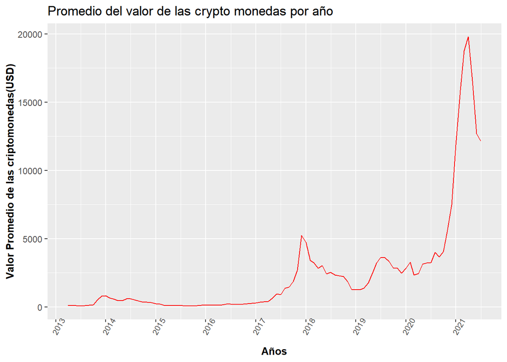

```r
value <- value_df_summary %>%
  ggplot() +
  geom_line(aes(x = as.Date(Date,format = "%y-%m-%d"), y = Avg_Value),color="red",fill="red")+
  labs(y="Valor Promedio de las criptomonedas(USD)", x="Años")+
  ggtitle("Promedio del valor de las crypto monedas por año ")+
  scale_x_date(date_breaks = "1 year",date_labels = "%Y")+
  theme(axis.title=element_text(size=10,face="bold"),axis.text.x = element_text(size = 8,angle = 60))
value
```

**Figura 3: Promedio del valor de las crypto monedas por año**

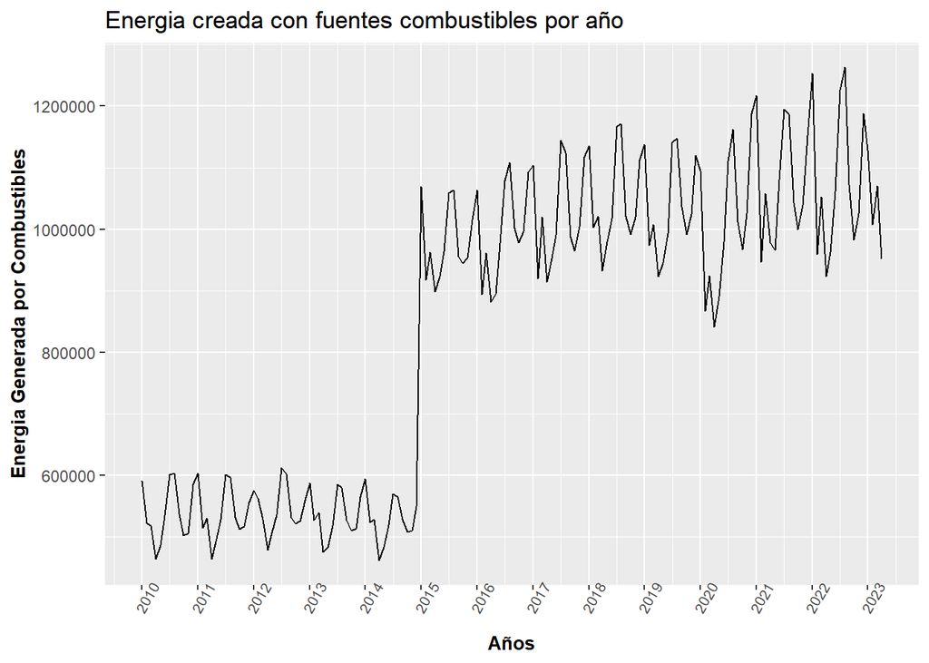

```r
power <- power_df %>%
  ggplot() +
  geom_line(aes(x = as.Date(Time,format = "%y-%m-%d"), y = Avg_amount),color="black",fill="black") +
  labs(y="Energia Generada por Combustibles", x="Años")+
  scale_x_date(date_breaks = "1 year",date_labels = "%Y")+
  ggtitle("Energia creada con fuentes combustibles por año")+
  theme(axis.title=element_text(size=10,face="bold"),axis.text.x = element_text(size = 8,angle = 60))
power
```

**Figura 4: Energia creada con fuentes combustibles por año**

Análisis energía creada con fuentes combustibles por año: Se evidencia el alto consumo de energía por año por múltiples factores: mayor presencia de la tecnología en el hogar, la pandemia de COVID-19, el uso de cripto-activos, etc.

la popularidad que ha obtenido en el tiempo, el aumento de sus transacciones,la reinversión que tuvo que hacer las empresas para mantener su valor en el tiempo etc etc. mencionado todo esto refleja un alto consumo con el pasar de los año.

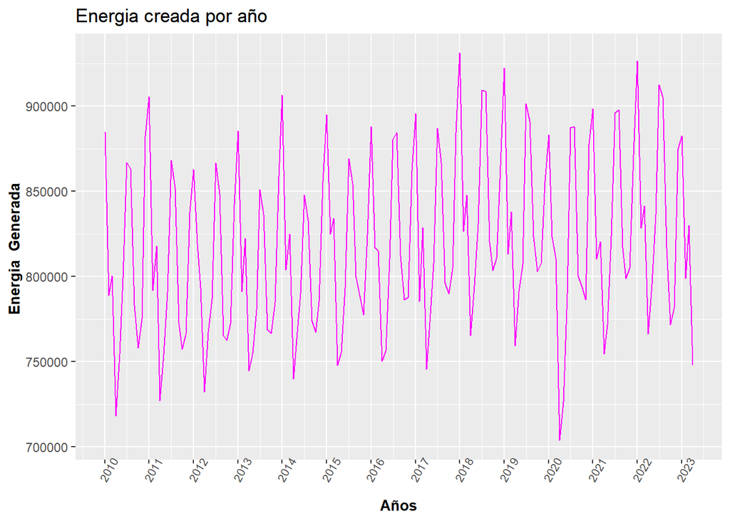

```r
power_total <- power_df_total %>%
  ggplot() +
  geom_line(aes(x = as.Date(Time,format = "%y-%m-%d"), y = Avg_amount),color="magenta",fill="magenta") +
  labs(y="Energia  Generada ", x="Años")+
  scale_x_date(date_breaks = "1 year",date_labels = "%Y")+
  ggtitle("Energia creada por año")+
  theme(axis.title=element_text(size=10,face="bold"),axis.text.x = element_text(size = 8,angle = 60))
power_total
```

**Figura 5: Energia creada por año**

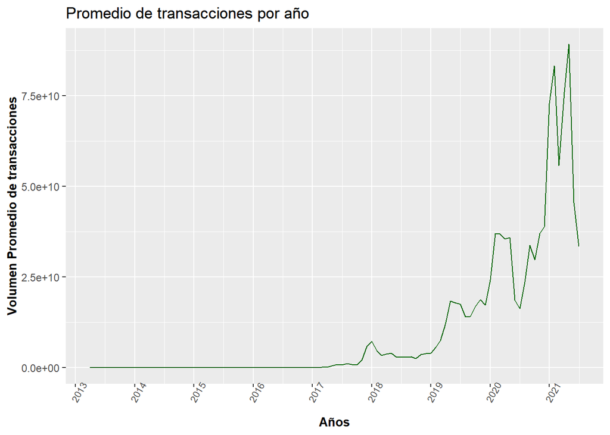

```r
volumen <- volumen_df_summary %>%
  ggplot() +
  geom_line(aes(x = as.Date(Date,format = "%y-%m-%d"), y = Volume),color="darkgreen",fill="darkgreen") +
  labs(y="Volumen Promedio de transacciones", x="Años")+
  scale_x_date(date_breaks = "1 year",date_labels = "%Y")+
  scale_y_continuous(labels = function(x) format(x, scientific = TRUE))+
  ggtitle("Promedio de transacciones por año")+
  theme(axis.title=element_text(size=10,face="bold"),axis.text.x = element_text(size = 8,angle = 60))
volumen
```

**Figura 6: Promedio de transacciones por año**

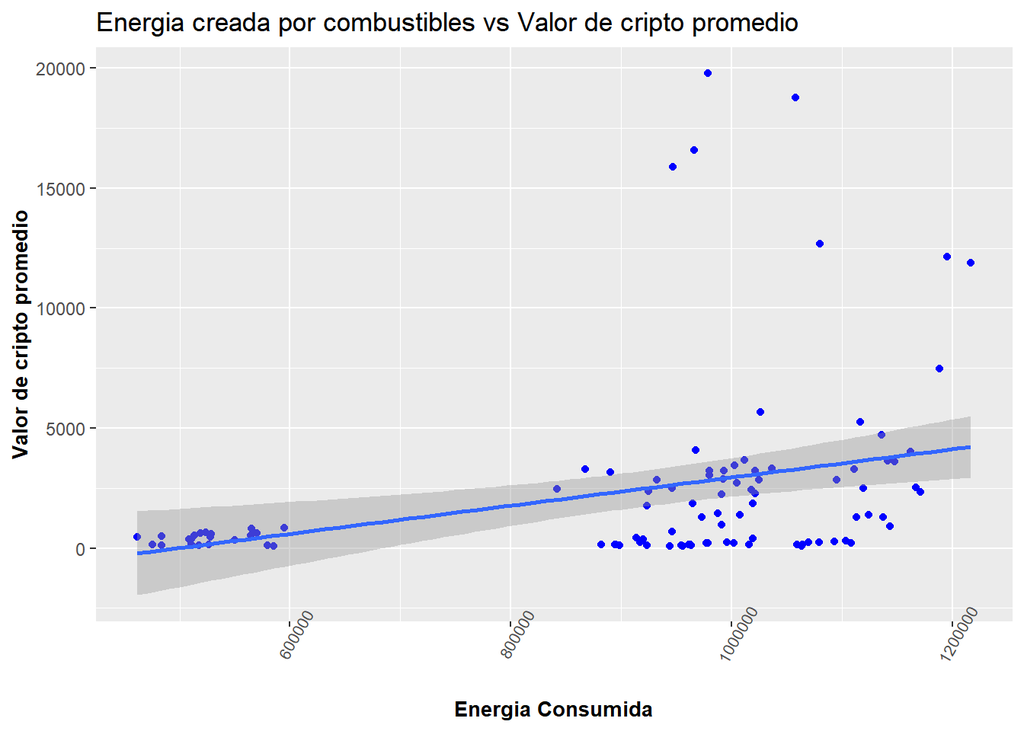

```r
power_value <-power_value_df %>%
  ggplot() +
  geom_point(aes(x = Avg_amount, y = Avg_Value),color="blue") +
  labs(y="Valor de cripto promedio", x="Energia Consumida")+
  ggtitle("Energia creada por combustibles vs Valor de cripto promedio")+
  stat_smooth(aes(x = Avg_amount, y = Avg_Value),method = "lm",
              formula = y ~ x,
              geom = "smooth")+
  theme(axis.title=element_text(size=10,face="bold"),axis.text.x = element_text(size = 8,angle = 60))
power_value
```

**Figura 7: Energia creada por combustibles vs Valor de cripto promedio**

```r
cor(power_value_df$Avg_Value,power_value_df$Avg_amount)
```

```
## [1] 0.3203233
```

Dando como correlacion entre valor de cripto promedio y energia consumida

Análisis Energía creada por combustible vs valor de cripto promedio: En este gráfico podemos apreciar: en esta gráfica se puede apreciar una mediana correlación positiva entre las variables energía creada por combustible vs valor de cripto promedio. reflejado que a medida que crece el valor crece la energía consumida.

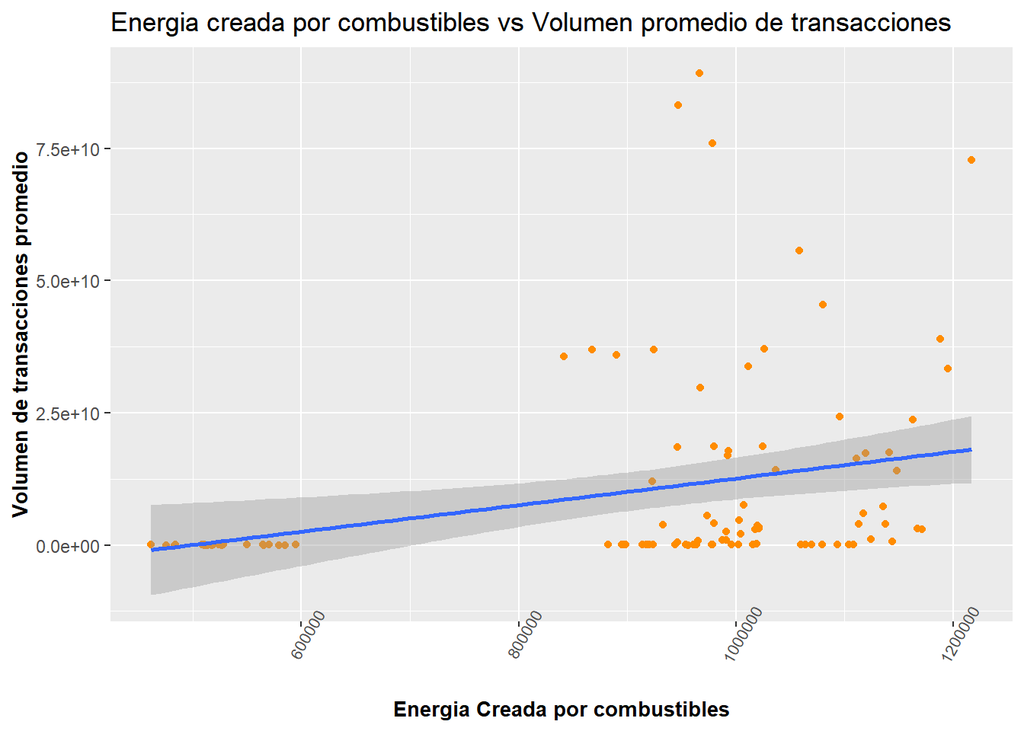

```r
power_volume <-power_volume_df %>%
  ggplot() +
  geom_point(aes(x = Avg_amount, y = Volume),color="darkorange") +
  labs(y="Volumen de transacciones promedio", x="Energia Creada por combustibles")+
  ggtitle("Energia creada por combustibles vs Volumen promedio de transacciones")+
  stat_smooth(aes(x = Avg_amount, y = Volume),method = "lm",
              formula = y ~ x,
              geom = "smooth")+
  theme(axis.title=element_text(size=10,face="bold"),axis.text.x = element_text(size = 8,angle = 60))
power_volume
```

**Figura 8: Energia creada por combustibles vs Volumen promedio de transacciones**

Análisis Energía creada por combustible vs volumen promedio de cripto: Se aprecia una mediana correlación positiva entre las variables energía creada por combustible vs volumen de promedio de las transacciones, cabe destacar que los valores tienen un pequeño sesgo ya que pocos son los que se acerca a la media, arrojando datos que tienen mayor valor energía creada por combustibles que por el volumen de las transacciones.

```r
cor(power_volume_df$Volume,power_volume_df$Avg_amount)
```

```
## [1] 0.2847213
```

Dando como correlacion entre volumen de transacciones promedio y energia creada por combustibles

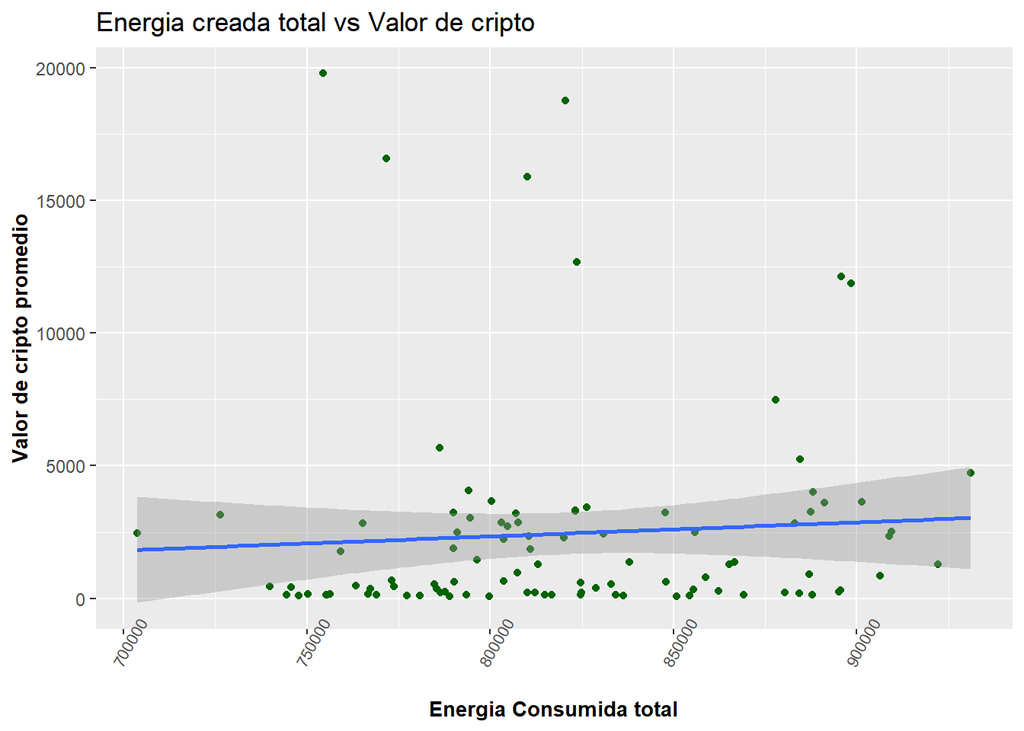

```r
power_total_value <-power_total_value_df %>%
  ggplot() +
  geom_point(aes(x = Avg_amount, y = Avg_Value),color="dark green") +
  labs(y="Valor de cripto promedio", x="Energia Consumida total")+
  ggtitle("Energia creada total vs Valor de cripto")+
  stat_smooth(aes(x = Avg_amount, y = Avg_Value),method = "lm",
              formula = y ~ x,
              geom = "smooth")+
  theme(axis.title=element_text(size=10,face="bold"),axis.text.x = element_text(size = 8,angle = 60))
power_total_value
```

**Figura 9: Energia creada total vs Valor de cripto**

Análisis del gráfico energía total vs valor de cripto: aquí se muestra una pequeña tendencia alza por ende existe una baja correlación positiva, un incremento en los datos por el eje x (energía consumida) que por el otro eje del eje y (valor promedio de las cripto promedio)

```r
cor(power_total_value_df$Avg_Value,power_total_value_df$Avg_amount)
```

```
## [1] 0.06700755
```

Dando como correlacion entre valor de cripto promedio y energia consumida total

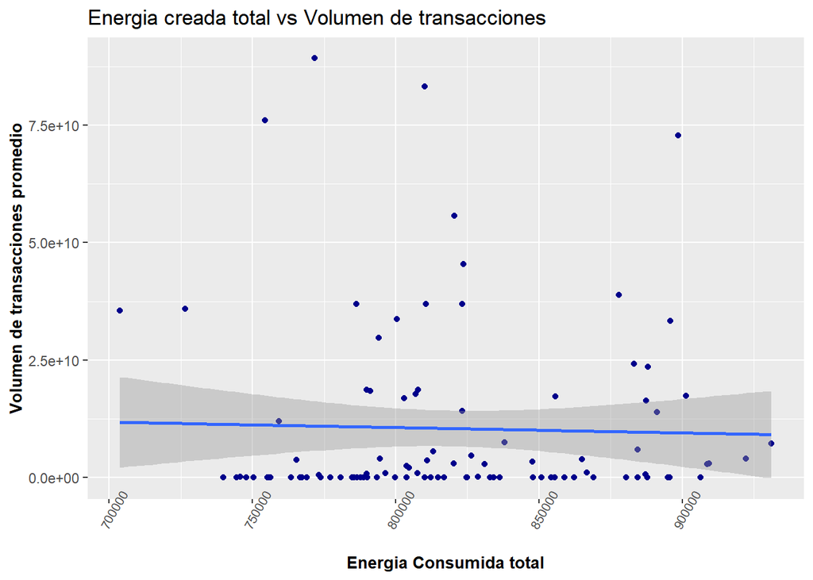

```r
power_total_volume <-power_total_volume_df %>%
  ggplot() +
  geom_point(aes(x = Avg_amount, y = Volume),color="dark blue") +
  labs(y="Volumen de transacciones promedio", x="Energia Consumida total")+
  ggtitle("Energia creada total vs Volumen de transacciones")+
  stat_smooth(aes(x = Avg_amount, y = Volume),method = "lm",
              formula = y ~ x,
              geom = "smooth")+
  theme(axis.title=element_text(size=10,face="bold"),axis.text.x = element_text(size = 8,angle = 60))
power_total_volume
```

**Figura 10: Energia creada total vs Volumen de transacciones**

Análisis del gráfico energía creada total vs volumen de transacciones: aquí se muestra una débil correlación negativo level en esta gráfica, a su vez como los dato muestran un poco sesgo, mostrando datos con mucha energía consumida que el valor propio de sus transacciones

```r
cor(power_total_volume_df$Volume,power_total_volume_df$Avg_amount)
```

```
## [1] -0.02998282
```

Dando como correlacion entre el volumen de transacciones promedio y la energia consumida total

## Preguntas

¿Es posible buscar una reducción de las emisiones de carbono con el uso constante de las cripto-activos? Si, ya que hoy en día tanto los gobiernos como empresas de cripto-activos establecieron medidas,regulaciones y reformas para preservar el medio ambiente.

¿A través de qué uso, cuáles son los instrumentos financieros que utilizarían para la reducción del daño ambiental? Bueno ante esta respuesta serian que las empresas de que prestan servicios de cripto-activos, y junto con las reformas de leyes medioambientales utilizaron parte de sus ganancias en pro de mejorar su eficiencia para reducir el daño ambiental a través de su consumo masivo de energía la ser utilizadas

¿Es de verdad preocupante el aumento masivo del uso de las cripto-activos para el medio ambiente? Si, debido a su impacto en los años recientes ¿Es cierto que ha aumentado el consumo de energía? Si, ya que ante el aumento de su popularidad y lo transparente de su sistema, han hecho que varias personas y empresas ingresaran sus activos como refugio, eso ha llevado un aumento de su valor por ende ante ese escenario decidieron aumentar el consumo de energía ya sea para emitir cripto-activos más o preservar su valor en el mercado

# Conclusión

## Principales hallazgos

Regresando al grafico de la figura 10 (Energia creada total vs Volumen de transacciones), No existe una fuerte correlación entre el volúmen de transacciones y la energía generada. Esto puede deberse a que el dataset seleccionado no considera patrones de consumo energético ni las transacciones de criptomonedas:

No parece existir correlación entre el la energía creada y el volumen de transacciones. Puede deberse a que el uso de energía en la minería de criptomonedas se realiza en todo el mundo, y la cantidad de energía utilizada por los mineros puede variar significativamente según el país, la región y la fuente de energía utilizada. Asimismo, es posible que los países considerados en el dataset no sean los principales generadores de criptomonedas.

# Referencias

- [The White House. (2022, Septiembre 08). Climate and Energy Implications of Crypto-Assets in the United States.](https://www.whitehouse.gov/ostp/news-updates/2022/09/08/fact-sheet-climate-and-energy-implications-of-crypto-assets-in-the-united-states/)
- [Apraez Muñoz, J. J., Guaitarilla Moncayo, D. F., & Muñoz Gómez, C. A. (2022). Análisis del impacto ambiental por el consumo energético en la producción del bitcoin a nivel mundial. LOGINN Investigación Científica Y Tecnológica, 6(2).](https://doi.org/10.23850/25907441.4800)
- [Cryptocurrency Historical Prices | Kaggle](https://www.kaggle.com/datasets/sudalairajkumar/cryptocurrencypricehistory?resource=download)
- [Energy Production and Consumption - Our World in Data](https://ourworldindata.org/energy-production-consumption)
- [Monthly Electricity Statistics - Data product - IEA](https://www.iea.org/data-and-statistics/data-product/monthly-electricity-statistics)
- [GitHub - owid/co2-data: Data on CO2 and greenhouse gas emissions by Our World in Data](https://github.com/owid/co2-data)
- [Dataset on bitcoin carbon footprint and energy consumption](https://figshare.com/articles/dataset/Dataset_on_bitcoin_carbon_footprint_and_energy_consumption/19442933/1)
- [GitHub: Proyecto de Ciencia de datos](https://github.com/AitorParr/Ciencia-De-Datos/tree/main)